# Paper Replication of Hypothesis Testing on Web-based Positive Psychology Interventions

2023-05-03

Paper: Web-Based Positive Psychology Interventions: A Reexamination of Effectiveness

References:

1. Woodworth, R. J., O’Brien-Malone, A., Diamond, M. R. and Schüz, B. (2017). Web-based positive psychology interventions: A reexamination of effectiveness. Journal of Clinical Psychology, 73(3), 218–232, DOI: https://doi.org/10.1002/jclp.22328
2. Woodworth, R. J., O’Brien-Malone, A., Diamond, M. R. and Schüz, B. (2018). Data from, ‘Web-based Positive Psychology Interventions: A Reexaminationof Effectiveness’. Journal of Open Psychology Data, DOI: https://doi.org/10.5334.jopd.35

Goal: Replicate various hypothesis testing methods for no difference between participants who completed all assessments vs participants who did not complete all assessments.

Intervention Groups:

- 1 “Using Signature Strengths”
- 2 “Three Good Things”
- 3 “Gratitude Visit”
- 4 “Recording early memories” (control condition)

# Load and Clean Data

## Creating New Variable: Status

- Before testing, I need to load the given datafile and create a new ordinal variable of status where a participant is either a ‘dropout’ or ‘non-dropout’. Dummy variables can also be used afterwards.

Load the data *ahi-cesd.csv* and *participant_info.csv*

```r
library(dplyr)
library(tidyverse)
```

```r
library(sjPlot)

library(lsr)
library(psych)
library(ggplot2)

# Disable scientific notation:
options(scipen=999, digits=4)

#Load Files
ahi_cesd <- read_csv("data/ahi-cesd.csv")
participant_info <- read_csv("data/participant-info.csv")
#View Files
head(ahi_cesd)
```

```
## # A tibble: 6 × 50
##      id occasion elaps…¹ inter…² ahi01 ahi02 ahi03 ahi04 ahi05 ahi06 ahi07 ahi08
##   <dbl>    <dbl>   <dbl>   <dbl> <dbl> <dbl> <dbl> <dbl> <dbl> <dbl> <dbl> <dbl>
## 1     1        0    0          4     2     3     2     3     3     2     3     3
## 2     1        1   11.8        4     3     3     4     3     3     4     4     3
## 3     2        0    0          1     3     4     3     4     2     3     4     3
## 4     2        1    8.02       1     3     4     4     4     3     3     4     4
## 5     2        2   14.3        1     3     4     4     4     3     3     4     3
## 6     2        3   32.0        1     3     4     4     4     4     4     4     3
## # … with 38 more variables: ahi09 <dbl>, ahi10 <dbl>, ahi11 <dbl>, ahi12 <dbl>,
## #   ahi13 <dbl>, ahi14 <dbl>, ahi15 <dbl>, ahi16 <dbl>, ahi17 <dbl>,
## #   ahi18 <dbl>, ahi19 <dbl>, ahi20 <dbl>, ahi21 <dbl>, ahi22 <dbl>,
## #   ahi23 <dbl>, ahi24 <dbl>, cesd01 <dbl>, cesd02 <dbl>, cesd03 <dbl>,
## #   cesd04 <dbl>, cesd05 <dbl>, cesd06 <dbl>, cesd07 <dbl>, cesd08 <dbl>,
## #   cesd09 <dbl>, cesd10 <dbl>, cesd11 <dbl>, cesd12 <dbl>, cesd13 <dbl>,
## #   cesd14 <dbl>, cesd15 <dbl>, cesd16 <dbl>, cesd17 <dbl>, cesd18 <dbl>, …
```

```r
head(participant_info)
```

```
## # A tibble: 6 × 6
##      id intervention   sex   age  educ income
##   <dbl>        <dbl> <dbl> <dbl> <dbl>  <dbl>
## 1     1            4     2    35     5      3
## 2     2            1     1    59     1      1
## 3     3            4     1    51     4      3
## 4     4            3     1    50     5      2
## 5     5            2     2    58     5      2
## 6     6            1     1    31     5      1
```

Using ahi_cesd for all known AHi and CESD scores, creating a new dataframe to perform functions that will help identify each unique participant’s status (dropout or non-dropout).

- Non-dropout defined as a participant with AHI and CESD scores provided in all 6 occasions.

```r
## count unique id with all recorded ocassion c(1,2,3,4,5)

library(hash)
#create new dataframe of ahi_cesd.csv
dat <- ahi_cesd

#create a new dictionary {id:occasion}
h <- hash()

# loop through each id and add the occasion's recorded
for (i in 1:nrow(dat)) {
  key <- as.character(dat[i,'id'])
  if (!has.key(key,h)) {
    h[key] <- deframe(dat[i,'occasion'])
  } else {
    h[key] <- append(h[[key]], deframe(dat[i,'occasion']) )
  }
}

#return the count of id that completed all c(1,2,3,4,5) occasions
completed <- c()

for (i in 1:length(h)) {
  #access key
  k <- keys( h[as.character(i)] )

  #access values
  v <- values(h[k],USE.NAMES=FALSE, simplify=FALSE)
  v <- v[[1]]

  #add key to completed vector
  if (all(v == c(0,1,2,3,4,5))) {
    completed = append(completed,i)
  }
}
```

Some pre-checks: Participants who completed at least the post-test(occasion == 1)

```r
# COMPLETED AT LEAST THE POSTTEST
completed_posttest <- c()

for (i in 1:length(h)) {
  #access key
  k <- keys( h[as.character(i)] )

  #access values
  v <- values(h[k],USE.NAMES=FALSE, simplify=FALSE)
  v <- v[[1]]

  #condition for any participant that completed the posttest (1)
  if (any(v %in% c(1))) {
    completed_posttest = append(completed_posttest,i)
  }
}
```

Now we have the correct counts of participants who completed all assessments, and an additional check of participants who at least completed the post-test(Occasion = 1).

```r
length(completed_posttest)
```

```
## [1] 147
```

```r
length(completed)
```

```
## [1] 72
```

Great! Now that we have created vectors of participant’s id under out conditions of completed or not, we can add a new column of dropout or non.dropout to the *participant_info* dataframe.

```r
# ADD NEW COLUMN OF DROPOUT AND NON.DROPOUT TO PARTICIPANTS

p.dat <- data.frame(participant_info)

p.dat <- participant_info %>%
  mutate(status = ifelse(id %in% completed, '1', '0'))

#pre_test_dat contains only occurences of Occasion = 0
pre_test_dat <- ahi_cesd %>%
  filter(occasion == 0)

#add column for
p.dat <- left_join(p.dat, pre_test_dat, by='id')

#select columns needed for the df
p.dat <- p.dat %>%
  select(id, intervention = intervention.x, sex, age, educ, income, status, ahiTotal, cesdTotal)

#ensure columns are the correct data type
p.dat$sex <- as.numeric(p.dat$sex)

head(p.dat)
```

```
## # A tibble: 6 × 9
##      id intervention   sex   age  educ income status ahiTotal cesdTotal
##   <dbl>        <dbl> <dbl> <dbl> <dbl>  <dbl> <chr>     <dbl>     <dbl>
## 1     1            4     2    35     5      3 0            63        14
## 2     2            1     1    59     1      1 1            73         7
## 3     3            4     1    51     4      3 0            77         3
## 4     4            3     1    50     5      2 0            60        31
## 5     5            2     2    58     5      2 0            41        27
## 6     6            1     1    31     5      1 0            62        25
```

```r
# ADD NEW COLUMN OF DROPOUT AND NON.DROPOUT TO AHI_CESD DF

initial.scores.dat <- ahi_cesd %>%
  filter(occasion == 0) %>%
  mutate(status = ifelse(id %in% completed, '1', '0')) %>%
  select(id, status, occasion, elapsed.days,intervention, ahiTotal, cesdTotal)

head(initial.scores.dat)
```

```
## # A tibble: 6 × 7
##      id status occasion elapsed.days intervention ahiTotal cesdTotal
##   <dbl> <chr>     <dbl>        <dbl>        <dbl>    <dbl>     <dbl>
## 1     1 0             0            0            4       63        14
## 2     2 1             0            0            1       73         7
## 3     3 0             0            0            4       77         3
## 4     4 0             0            0            3       60        31
## 5     5 0             0            0            2       41        27
## 6     6 0             0            0            1       62        25
```

Done! This table will be the main df to work on various hypothesis testing to see if there is a difference between participants that completed all assessments and participants that did not complete all assessments. This precaution is done so to move forward with the paper’s intention-to-treat experiment to test ANOVA on the effects of 3 different positive psychology interventions and a control(placebo) over time.

# T-Test on Initial Happiness and Depression Scores

## Initial Happiness Scores

AHI Scores with t.test

H_0: No difference between AHI scores of dropout and non.dropouts

Checking data for violations of Assumptions of T-Test - relatively equal group sizes - relatively equal variances - interval or continuous variable is normally distributed

Paper: initial happiness scores, t(293) = 0.26, p = .79

```r
#Check equal variances for T-Test
var.test(ahiTotal ~ status, data = p.dat)
```

```
##
##  F test to compare two variances
##
## data:  ahiTotal by status
## F = 1.2, num df = 222, denom df = 71, p-value = 0.4
## alternative hypothesis: true ratio of variances is not equal to 1
## 95 percent confidence interval:
##  0.808 1.729
## sample estimates:
## ratio of variances
##              1.204
```

```r
# Shapiro-Wilk normality test for NonDropout's ahiTotal
with(p.dat, shapiro.test(ahiTotal[status == "1"]))# p = 0.7
```

```
##
##  Shapiro-Wilk normality test
##
## data:  ahiTotal[status == "1"]
## W = 0.99, p-value = 0.7
```

```r
# Shapiro-Wilk normality test for Dropout's ahiTotal
with(p.dat, shapiro.test(ahiTotal[status == "0"])) # p = 0.9
```

```
##
##  Shapiro-Wilk normality test
##
## data:  ahiTotal[status == "0"]
## W = 1, p-value = 0.9
```

Both tests of equal variance and Shapiro-Wilk normality test provided p-values that were not statistically significant to reject the null hypothesis. continuing the t-test.

```r
res.ahiTotal <- t.test(
  ahiTotal~status,
  data = p.dat,
  var.equal=TRUE,
  conf.level = 0.95,
  alternative = "two.sided"
)
res.ahiTotal
```

```
##
##  Two Sample t-test
##
## data:  ahiTotal by status
## t = -0.47, df = 293, p-value = 0.6
## alternative hypothesis: true difference in means between group 0 and group 1 is not equal to 0
## 95 percent confidence interval:
##  -4.348  2.686
## sample estimates:
## mean in group 0 mean in group 1
##           69.50           70.33
```

```r
res.ahiTotal$p.value
```

```
## [1] 0.6423
```

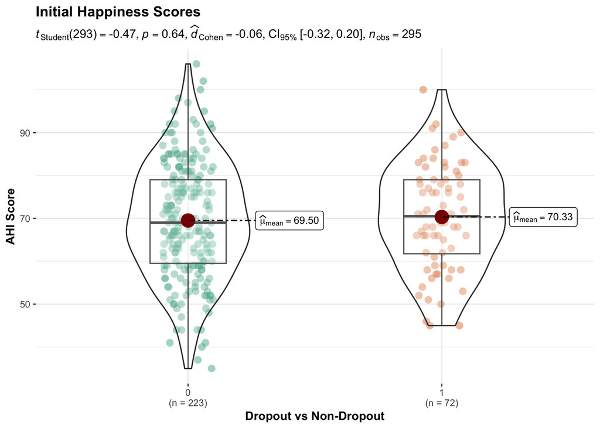

```r
ggstatsplot::ggbetweenstats(data = p.dat, x = status, y = ahiTotal,
                            var.equal = TRUE,
                            effsize.type = "d", mean.ci = TRUE,
                            pairwise.comparisons = FALSE,
                            messages = FALSE, bf.message = FALSE,
                            title = "Initial Happiness Scores", xlab = "Dropout vs Non-Dropout", ylab = "AHI Score")
```

**Initial AHI scores between dropout and non.dropout groups do not show statistically significant results (p = 0.64) , and we retain the null hypothesis that there is no difference.**

## Initial Depression Scores

CESD Scores with t.test

H_0: No difference between AHI scores of dropout and non.dropouts

Checking data for violations of Assumptions of T-Test - relatively equal group sizes - relatively equal variances - interval or continuous variable is normally distributed

Paper: initial depression scores t(293) = 0.44, p = .66

```r
#Check equal variances for T-Test
var.test(cesdTotal ~ status, data = p.dat) # p = 0.4
```

```
##
##  F test to compare two variances
##
## data:  cesdTotal by status
## F = 1.2, num df = 222, denom df = 71, p-value = 0.4
## alternative hypothesis: true ratio of variances is not equal to 1
## 95 percent confidence interval:
##  0.7964 1.7041
## sample estimates:
## ratio of variances
##              1.187
```

```r
# Shapiro-Wilk normality test for NonDropout's ahiTotal
with(p.dat, shapiro.test(cesdTotal[status == "1"]))# p = 0.0003
```

```
##
##  Shapiro-Wilk normality test
##
## data:  cesdTotal[status == "1"]
## W = 0.92, p-value = 0.0003
```

```r
# Shapiro-Wilk normality test for Dropout's ahiTotal
with(p.dat, shapiro.test(cesdTotal[status == "0"])) # p = 0.000000007
```

```
##
##  Shapiro-Wilk normality test
##
## data:  cesdTotal[status == "0"]
## W = 0.93, p-value = 0.000000007
```

```r
#Since normality test failed, a wilcoxon test serves as another test of differences
wilcox.test(cesdTotal ~ status, data = p.dat, alternative = "two.sided")
```

```
##
##  Wilcoxon rank sum test with continuity correction
##
## data:  cesdTotal by status
## W = 8836, p-value = 0.2
## alternative hypothesis: true location shift is not equal to 0
```

```r
# Initial Depression Scores
#Paper's initial depression scores t(293) = 0.44, p = .66

res.cesdTotal <- t.test(
  cesdTotal ~ status,
  data = p.dat,
  var.equal=TRUE,
  conf.level = 0.95,
  alternative="two.sided"
)

res.cesdTotal
```

```
##
##  Two Sample t-test
##
## data:  cesdTotal by status
## t = 1.3, df = 293, p-value = 0.2
## alternative hypothesis: true difference in means between group 0 and group 1 is not equal to 0
## 95 percent confidence interval:
##  -0.9538  4.7989
## sample estimates:
## mean in group 0 mean in group 1
##           15.53           13.61
```

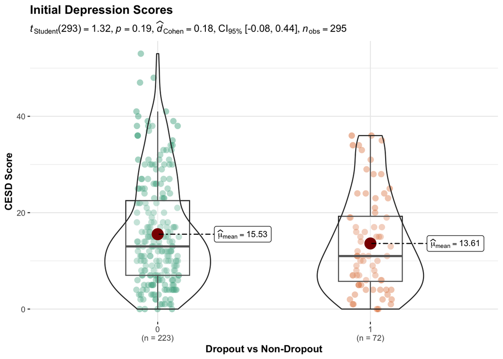

```r
ggstatsplot::ggbetweenstats(data = p.dat, x = status, y = cesdTotal,
                            var.equal = TRUE,
                            effsize.type = "d", mean.ci = TRUE,
                            pairwise.comparisons = FALSE,
                            messages = FALSE, bf.message = FALSE,
                            title = "Initial Depression Scores", xlab = "Dropout vs Non-Dropout", ylab = "CESD Score")
```

# Hypothesis Testing on Demographic Variables

## Difference in Sex with Chi-Square Test

Using Chi-Square Test to see comparison of female and male samples.

Hypothesis: There is no difference between the sample of male and female among dropout and non.dropout participants.

```r
#H_0:
#  P_160 = P61 (same probability of male)
#  P_33 = P_11 (same probability of female)

# Create crosstabulations
sexfreq <- xtabs(formula = ~sex + status, data = p.dat)

chisq.test(sexfreq, correct = FALSE)    # X-squared = 0.01, df = 1, p-value = 0.92
```

```
##
##  Pearson's Chi-squared test
##
## data:  sexfreq
## X-squared = 0.0099, df = 1, p-value = 0.9
```

```r
# correct = FALSE. logical indicating whether to apply continuity correction when computing test statistic for 2x2 tables.
```

Differences in Sex

| sex | status |  | Total |  |
| --- | --- | --- | --- | --- |
|  | 0 | 1 |  |  |
| 1 | 190 75.7 % | 61 24.3 % |  | 251 100 % |
| 2 | 33 75 % | 11 25 % | 44 100 % |  |
| Total | 223 75.6 % | 72 24.4 % | 295 100 % |  |

## Intervention Groups with Chi-Square Test

X-squared(3, n = 295) = 6.15, p = 0.11

H_0: No difference between intervention groups of dropout and non.dropouts

Issues: not getting the p = 0.11….could be a round up of a round up….

```r
intervention.freq <- xtabs(formula = ~intervention+status, data = p.dat)
chisq.test(intervention.freq, ) # X-squared = 6.143, p = 0.1046
```

```
##
##  Pearson's Chi-squared test
##
## data:  intervention.freq
## X-squared = 6.1, df = 3, p-value = 0.1
```

```r
sjPlot::tab_xtab(
  var.row = p.dat$intervention,
  var.col = p.dat$status,
  statistics = "cramer",
  title = "Differences in Intervention",
  show.exp = TRUE,
  show.row.prc = TRUE)
```

Differences in Intervention

| intervention | status |  | Total |  |
| --- | --- | --- | --- | --- |
|  | 0 | 1 |  |  |
| 1 | 55 54 76.4 % | 17 18 23.6 % |  | 72 72 100 % |
| 2 | 52 57 68.4 % | 24 19 31.6 % | 76 76 100 % |  |
| 3 | 63 56 85.1 % | 11 18 14.9 % | 74 74 100 % |  |
| 4 | 53 55 72.6 % | 20 18 27.4 % | 73 73 100 % |  |
| Total | 223 223 75.6 % | 72 72 24.4 % | 295 295 100 % |  |

## Difference in Education Level with Wilcoxon Test

Wilcoxon W = 8154, p =.83

H_0: No difference between intervention groups of dropout and non.dropouts

```r
wilcox.test(x = p.dat$educ[p.dat$status == '1'],
            y = p.dat$educ[p.dat$status == '0'],
            alternative = "two.sided")
```

```
##
##  Wilcoxon rank sum test with continuity correction
##
## data:  p.dat$educ[p.dat$status == "1"] and p.dat$educ[p.dat$status == "0"]
## W = 8154, p-value = 0.8
## alternative hypothesis: true location shift is not equal to 0
```

## Difference in Income Level with Wilcoxon Test

Income with wilcoxon test Wilcoxon W = 8552, p = .37

H_0: No difference between intervention groups of dropout and non.dropouts

```r
wilcox.test(x = p.dat$income[p.dat$status == '1'],
            y = p.dat$income[p.dat$status == '0'],
            alternative = "two.sided")
```

```
##
##  Wilcoxon rank sum test with continuity correction
##
## data:  p.dat$income[p.dat$status == "1"] and p.dat$income[p.dat$status == "0"]
## W = 8552, p-value = 0.4
## alternative hypothesis: true location shift is not equal to 0
```

## Difference in Age with T-Test

H_0: No difference between intervention groups of dropout and non.dropouts

Checking data for violations of Assumptions of T-Test - relatively equal group sizes - relatively equal variances - interval or continuous variable is normally distributed

```r
#Test of equal variance
var.test(age ~ status, data = p.dat)
```

```
##
##  F test to compare two variances
##
## data:  age by status
## F = 1.1, num df = 222, denom df = 71, p-value = 0.6
## alternative hypothesis: true ratio of variances is not equal to 1
## 95 percent confidence interval:
##  0.7474 1.5992
## sample estimates:
## ratio of variances
##              1.114
```

```r
t.test(
  age ~ status,
  data = p.dat,
  var.equal=FALSE,
  conf.level = 0.95
)
```

```
##
##  Welch Two Sample t-test
##
## data:  age by status
## t = -3.3, df = 126, p-value = 0.001
## alternative hypothesis: true difference in means between group 0 and group 1 is not equal to 0
## 95 percent confidence interval:
##  -8.490 -2.105
## sample estimates:
## mean in group 0 mean in group 1
##           42.47           47.76
```